# Lectura/Escritura en R

## Modos de texto I

- `dumping` y `dputing` son útiles porque el archivo que resulta es en un formato que se puede corregir, y en caso de que el archivo se degrade, potencialmente se puede recuperar.
- A diferencia de escribir los resultados en una tabla o en un formato `csv`, `dump` y `dput` mantiene la información de `metadatos` (sacrificando algo de legibilidad), de tal manera que otro usuario no tendría que reconstruir el objeto de nuevo.

## Modos de texto II

- Los modos de texto funcionan mejor para interactuar con programas que llevan el seguimiento de cambios de archivo tipo texto.
- Este modo sigue la "filosofía linux" en lo que respecta a archivos.
- Desventaja: No es eficiente en el uso del espacio.

## Ejemplo I

```r
y <- data.frame(a = 1:6, b = letters[1:6])
y
```

```
##   a b
## 1 1 a
## 2 2 b
## 3 3 c
## 4 4 d
## 5 5 e
## 6 6 f
```

```r
dput(y)
```

```
## structure(list(a = 1:6, b = structure(1:6, .Label = c("a", "b",
## "c", "d", "e", "f"), class = "factor")), .Names = c("a", "b"), row.names = c(NA,
## -6L), class = "data.frame")
```

```r
dput(y, file = "y.R")
nuevo.y <- dget("y.R")
nuevo.y
```

```
##   a b
## 1 1 a
## 2 2 b
## 3 3 c
## 4 4 d
## 5 5 e
## 6 6 f
```

## Ejemplo II

```r
x <- "foo"
y <- data.frame(a = 6:1, b = letters[6:1])
dump(c("x", "y"), file = "datos.R")
rm(x, y)
source("datos.R")
y
```

```
##   a b
## 1 6 f
## 2 5 e
## 3 4 d
## 4 3 c
## 5 2 b
## 6 1 a
```

```r
x
```

```
## [1] "foo"
```

## Interfaces al mundo exterior

- `file`, abre una conexión a algún archivo.
- `gzfile`, abre una conexión a un archivo comprimido con gzip.
- `bzfile`, abre una conexión a un archivo comprimido con bzip2.
- `url`, abre una conexión a una página web.

## Conexión tipo "file"

```r
str(file)
```

```
## function (description = "", open = "", blocking = TRUE, encoding = getOption("encoding"),
##     raw = FALSE)
```

- `description` es el nombre del archivo.
- `open` es un código que indica
- `r` solo lectura.
- `w` escritura (inicia un nuevo archivo).
- `a` adición a un archivo.
- `rb`, `rb`, `ab`, lectura, escritura y adición en modo binario (únicamente en `windows`)

## Conexiones

```r
con <- file("foo.txt", "r")
datos <- read.csv(con)
close(con)
```

equivale a:

```r
datos <- read.csv("foo.txt")
```

## Lectura de página web.

```r
urlbTRM <- readLines("url_bancol_trm.txt")
urlbTRM
```

```
## [1] "http://obiee.banrep.gov.co/analytics/saw.dll?Go&NQUser=publico&NQPassword=publico&Path=/shared/Consulta%20Series%20Estadisticas%20desde%20Excel/1.%20Tasa%20de%20Cambio%20Peso%20Colombiano/1.1%20TRM%20-%20Disponible%20desde%20el%2027%20de%20noviembre%20de%201991/1.1.1%20Serie%20historica&Opti…
```

```r
con <- url(urlbTRM, "r")
x <- readLines(con)
close(con)
```

```r
head(x, 200)
```

```
##   [1] "<!DOCTYPE HTML PUBLIC \"-//W3C//DTD HTML 4.0//EN\">"
##   [2] "<html dir=\"ltr\" xmlns=\"http://www.w3.org/1999/xhtml\" xml:lang=\"en\" lang=\"en\">"
##   [3] "<head>"
##   [4] "<meta http-equiv=\"Content-Type\" content=\"text/html; charset=utf-8\">"
##   [5] "<meta http-equiv=\"Content-Language\" content=\"en\">"
##   [6] "<title>1.1.1 Serie historica</title>"
##   [7] "<script language=\"javascript\">"
##   [8] "function sawFixupPrefix(sPrefix,s) { return sPrefix.replace('__xyz__',s); }"
##   [9] "function sawCommandToURLImpl(s, bFull) { var sPrefix=\"saw.dll?__xyz__&_scid=cyHMTmxWUBc\";"
##  [10] "if (bFull && sPrefix.indexOf('http') > 0) return document.location.href.substring(0, document.location.href.indexOf('sPrefix')) + sawFixupPrefix(sPrefix,s);"
##  [11] "else return sawFixupPrefix(sPrefix,s); }"
##  [12] "function restrictLength(field, maxlimit) { if (field.value.length > maxlimit) { field.value = field.value.substring(0, maxlimit); } }"
##  [13] "var sawEmptyHtm = \"res/empty.htm\";"
##  [14] "var g_LocaleInfo = {sDateSeparator:\"/\",sTimeSeparator:\":\",sDecimalPoint:\".\",sThousandsSeparator:\",\",sAM:\"AM\",sPM:\"PM\",nFDOW:6,b24:false,sDateOrder:\"dmy\",nYearPadding:4,nMonthPadding:2,nDayPadding:2,nHourPadding:2,sListSeparator:\";\"};"
##  [15] "</script>"
```

[output cut: 185 more lines]

```r
tail(x, 200)
```

```
##   [1] "<tr>"
##   [2] "<td class=\"PTROW1 PTRIL PTE OOCD\" style=\"width:10%;\" DVal=\"date &#39;2015-01-26&#39;\">26/01/2015</td>"
##   [3] "<td class=\"PTC PTE OORD\" style=\"width:30%;\">$2,386.50</td>"
##   [4] "</tr>"
##   [5] "<tr>"
##   [6] "<td class=\"PTROW1 PTRIL OOCD\" style=\"width:10%;\" DVal=\"date &#39;2015-01-27&#39;\">27/01/2015</td>"
##   [7] "<td class=\"PTC OORD\" style=\"width:30%;\">$2,386.28</td>"
##   [8] "</tr>"
##   [9] "<tr>"
##  [10] "<td class=\"PTROW1 PTRIL PTE OOCD\" style=\"width:10%;\" DVal=\"date &#39;2015-01-28&#39;\">28/01/2015</td>"
##  [11] "<td class=\"PTC PTE OORD\" style=\"width:30%;\">$2,381.11</td>"
##  [12] "</tr>"
##  [13] "<tr>"
##  [14] "<td class=\"PTROW1 PTRIL OOCD\" style=\"width:10%;\" DVal=\"date &#39;2015-01-29&#39;\">29/01/2015</td>"
##  [15] "<td class=\"PTC OORD\" style=\"width:30%;\">$2,362.42</td>"
```

[output cut: 185 more lines]

## Recuperar el valor de la TRM desde enero 1 hasta hoy

```r
require(stringr)
fechas <- str_extract(x, "[0-9]{2}/[0-9]{2}/[0-9]{4}")
valores <- str_extract(x, "[0-9][\\,][0-9]{3}.[0-9]{2}")
fechas <- fechas[!is.na(fechas)]
fechas <- as.POSIXct(strptime(fechas, format = "%d/%m/%Y"))
valores <- valores[!is.na(valores)]
valores <- str_replace(valores, "[\\,]","")
valores <- as.numeric(valores)
trm <- data.frame(fechas, valores)
```

```r
head(trm)
```

```
##       fechas valores
## 1 2015-01-01 2392.46
## 2 2015-01-02 2392.46
## 3 2015-01-03 2383.37
## 4 2015-01-04 2383.37
## 5 2015-01-05 2383.37
## 6 2015-01-06 2412.82
```

## Gráfica de la TRM hasta hoy I

### Con graficación básica

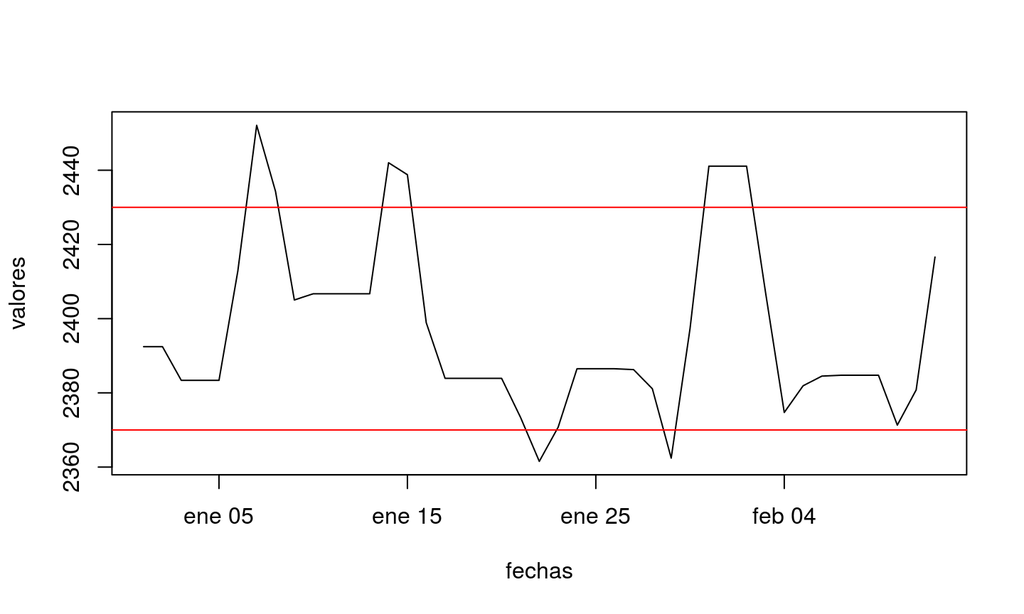

```r
plot(trm, type = "l")
abline(h = c(2370,2430), col = "red")
```

## Gráfica de la TRM hasta hoy II

### Con lattice

```r
require(lattice)
```

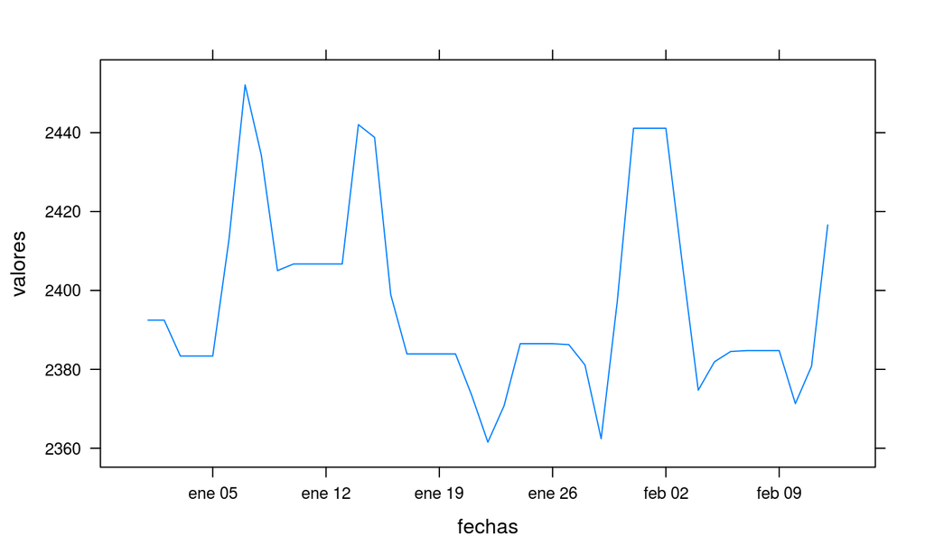

```r
xyplot(valores ~ fechas, data = trm, type = "l")
```

## Gráfica de la TRM hasta hoy III

### Con ggplot2

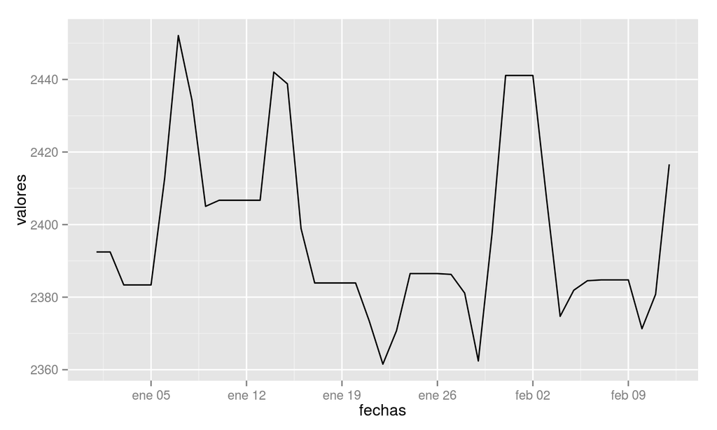

```r
require(ggplot2)
g1 <- ggplot(trm, aes(fechas, valores)) + geom_line()
g1
```